# Mapping with Geopandas

One of the nice features of geopandas is its built-in mapping functionality. This makes it really simple to visualize your data as you manipulate it in the database. It is built ontop of matplotlib, so you can quickly add more functionality to your maps beyond some of the defaults.

There are three datafiles associated with this chapter: ne_10m_admin_1_states_provinces_aus, ne_10m_populated_places_simple_aus, and ne_10m_railroads_aus. One each for the three geometric primitives: points, polylines, and polygons. This way you can see how each behaves while being mapped. The data comes from Natural Earth, and has been selected for all of Australia. Also, and this is important, **they all have the same spatial reference system**: http://spatialreference.org/ref/epsg/gda94-geoscience-australia-lambert/ Australian Geoscience Lambert projection. This is important so the maps will line up properly. You could change the projection using Geopandas, but I'd rather focus primarily on visualizing in this chapter.

We first need to import the proper libraries. Working inside Jupyter Notebook, I will also set matplotlib to inline.

```python
import geopandas as gpd
%matplotlib inline
```

Now we can read the files. I have the Jupyter Notebook in a parent folder to the data folder, so my paths may be different from where you keep your files. I'll use a descriptive variable name for each of the new padas dataframes. Let's also print out one of the layers so we can see the structure of the data. Using `list()` around the pandas dataframe returns a list of the column names.

```python
admin = gpd.read_file("Data/ne_10m_admin_1_states_provinces_aus.shp")
populated = gpd.read_file("Data/ne_10m_populated_places_simple_aus.shp")
railroads = gpd.read_file("Data/ne_10m_railroads_aus.shp")
print(list(admin))
```

[output not shown]

As you can see there is the standard geometry column name that is added from the data after it was read from the shapefile. Geopandas dataframes include a plot function that will automatically create a matplotlib figure.

We can also print out the coordinate reference system, map projection, for each dataframe to confirm they are the same.

```python
print(admin.crs)
print(populated.crs)
print(railroads.crs)
```

```
{u'lon_0': 134, u'ellps': u'GRS80', u'y_0': 0, u'no_defs': True, u'proj': u'lcc', u'x_0': 0, u'units': u'm', u'lat_2': -36, u'lat_1': -18, u'lat_0': 0}
{u'lon_0': 134, u'ellps': u'GRS80', u'y_0': 0, u'no_defs': True, u'proj': u'lcc', u'x_0': 0, u'units': u'm', u'lat_2': -36, u'lat_1': -18, u'lat_0': 0}
{u'lon_0': 134, u'ellps': u'GRS80', u'y_0': 0, u'no_defs': True, u'proj': u'lcc', u'x_0': 0, u'units': u'm', u'lat_2': -36, u'lat_1': -18, u'lat_0': 0}
```

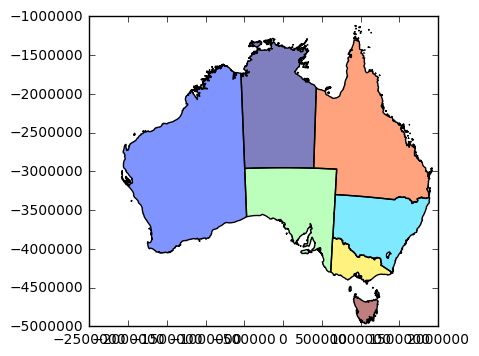

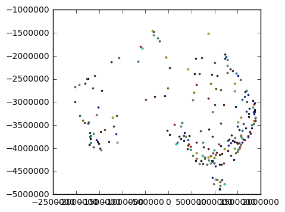

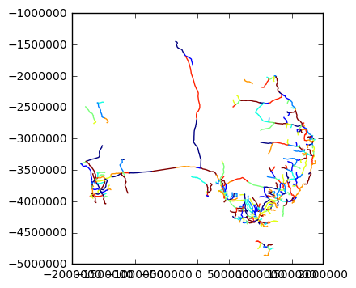

```python
admin.plot()
populated.plot()
railroads.plot()
```

That's nice if we want to see each layer individually, but that's not really a *map* is it? We want to explore the *relationship* between the features. We need to seem them all overlaid. To do that, we need to establish a figure first, and an axes object, then pass that to the plot function. Some of matplotlib was covered in a previous chapter, and will not be covered here. If you jumped to this section this may be a little confusing.

Begin by importing matplotlib:

```python
import matplotlib.pyplot as plt
```

Then creating a new subplot which returns figure and axes objects. I've set the figure size to 6x6 inches. Then set the aspect ratio to equal, which works best for mapping. This means we will scale both the x and y axes equally. Now when we call the plot function on each of the dataframes, we pass the ax argument with the axes from our subplot. This means that each dataframe will be plotted in the same figure.

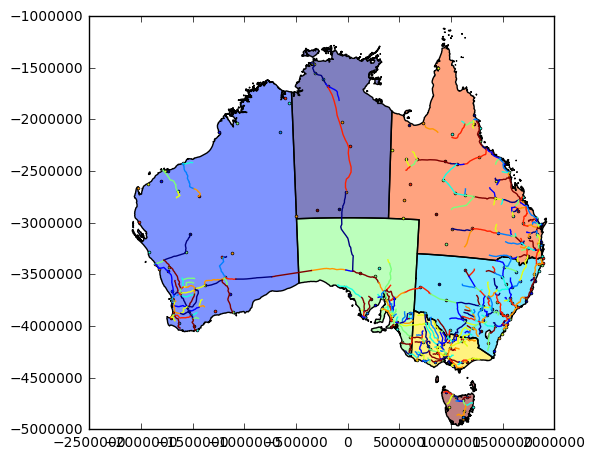

```python
fig, ax = plt.subplots(figsize=(6,6))
ax.set_aspect('equal')
admin.plot(ax=ax)
populated.plot(ax=ax)
railroads.plot(ax=ax)
```

Right now, it is producing a categorical plot. That is, each feature in each data frame gets a unique color. We can change this by setting some of the style settings for a matplotlib plot. For example, we can set the line color and the fill color for the polygons.

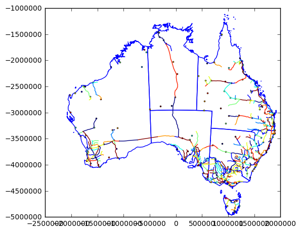

```python
fig, ax = plt.subplots(figsize=(6,6))
ax.set_aspect('equal')
admin.plot(ax=ax,color='white',edgecolor='blue')
populated.plot(ax=ax)
railroads.plot(ax=ax)
```

Now we can modify the *marker* or points in terms of shape, color, and size. The `'k'` is shorthand for black. Many of the standard colors can be set using only a single letter. This saves some time typing, but decreases the legibility of your code (unless you are familiar with matplotlib).

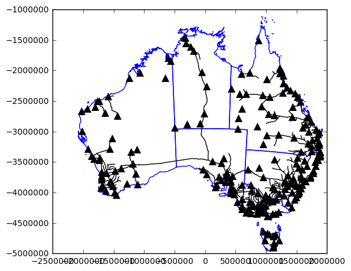

```python
fig, ax = plt.subplots(figsize=(6,6))
ax.set_aspect('equal')
admin.plot(ax=ax,color='white',edgecolor='blue')
populated.plot(ax=ax,color='k',marker='^',markersize=8)
railroads.plot(ax=ax, color='k')
```